# Risk Factor Analysis

## Outcome Variable

**Outcome Variable:** ever_wasted

## Predictor Variables

**Intervention Variable:** enstunt

**Adjustment Set:**

- arm
- sex
- W_mage
- meducyrs
- feducyrs
- vagbrth
- single
- brthmon
- W_parity
- delta_W_mage
- delta_meducyrs
- delta_feducyrs
- delta_vagbrth
- delta_single
- delta_brthmon
- delta_W_parity

## Stratifying Variables

The analysis was stratified on these variable(s):

- agecat
- studyid
- country

## Data Summary

| agecat | studyid | country | enstunt | ever_wasted | n_cell | n |
| --- | --- | --- | --- | --- | --- | --- |
| 0-24 months (no birth wast) | CMC-V-BCS-2002 | INDIA | 0 | 0 | 166 | 368 |
| 0-24 months (no birth wast) | CMC-V-BCS-2002 | INDIA | 0 | 1 | 127 | 368 |
| 0-24 months (no birth wast) | CMC-V-BCS-2002 | INDIA | 1 | 0 | 36 | 368 |
| 0-24 months (no birth wast) | CMC-V-BCS-2002 | INDIA | 1 | 1 | 39 | 368 |
| 0-24 months (no birth wast) | CMIN | BANGLADESH | 0 | 0 | 103 | 268 |
| 0-24 months (no birth wast) | CMIN | BANGLADESH | 0 | 1 | 63 | 268 |
| 0-24 months (no birth wast) | CMIN | BANGLADESH | 1 | 0 | 50 | 268 |
| 0-24 months (no birth wast) | CMIN | BANGLADESH | 1 | 1 | 52 | 268 |
| 0-24 months (no birth wast) | COHORTS | GUATEMALA | 0 | 0 | 910 | 1332 |
| 0-24 months (no birth wast) | COHORTS | GUATEMALA | 0 | 1 | 103 | 1332 |
| 0-24 months (no birth wast) | COHORTS | GUATEMALA | 1 | 0 | 263 | 1332 |
| 0-24 months (no birth wast) | COHORTS | GUATEMALA | 1 | 1 | 56 | 1332 |
| 0-24 months (no birth wast) | COHORTS | INDIA | 0 | 0 | 5189 | 7135 |
| 0-24 months (no birth wast) | COHORTS | INDIA | 0 | 1 | 1099 | 7135 |
| 0-24 months (no birth wast) | COHORTS | INDIA | 1 | 0 | 636 | 7135 |
| 0-24 months (no birth wast) | COHORTS | INDIA | 1 | 1 | 211 | 7135 |
| 0-24 months (no birth wast) | COHORTS | PHILIPPINES | 0 | 0 | 2004 | 3019 |
| 0-24 months (no birth wast) | COHORTS | PHILIPPINES | 0 | 1 | 841 | 3019 |
| 0-24 months (no birth wast) | COHORTS | PHILIPPINES | 1 | 0 | 99 | 3019 |
| 0-24 months (no birth wast) | COHORTS | PHILIPPINES | 1 | 1 | 75 | 3019 |
| 0-24 months (no birth wast) | CONTENT | PERU | 0 | 0 | 192 | 215 |
| 0-24 months (no birth wast) | CONTENT | PERU | 0 | 1 | 3 | 215 |
| 0-24 months (no birth wast) | CONTENT | PERU | 1 | 0 | 19 | 215 |
| 0-24 months (no birth wast) | CONTENT | PERU | 1 | 1 | 1 | 215 |
| 0-24 months (no birth wast) | EE | PAKISTAN | 0 | 0 | 111 | 377 |
| 0-24 months (no birth wast) | EE | PAKISTAN | 0 | 1 | 100 | 377 |
| 0-24 months (no birth wast) | EE | PAKISTAN | 1 | 0 | 63 | 377 |
| 0-24 months (no birth wast) | EE | PAKISTAN | 1 | 1 | 103 | 377 |
| 0-24 months (no birth wast) | GMS-Nepal | NEPAL | 0 | 0 | 275 | 660 |
| 0-24 months (no birth wast) | GMS-Nepal | NEPAL | 0 | 1 | 278 | 660 |

[output cut: 338 more lines]

The following strata were considered:

- agecat: 0-24 months (no birth wast), studyid: CMC-V-BCS-2002, country: INDIA
- agecat: 0-24 months (no birth wast), studyid: CMIN, country: BANGLADESH
- agecat: 0-24 months (no birth wast), studyid: COHORTS, country: GUATEMALA
- agecat: 0-24 months (no birth wast), studyid: COHORTS, country: INDIA
- agecat: 0-24 months (no birth wast), studyid: COHORTS, country: PHILIPPINES
- agecat: 0-24 months (no birth wast), studyid: CONTENT, country: PERU
- agecat: 0-24 months (no birth wast), studyid: EE, country: PAKISTAN
- agecat: 0-24 months (no birth wast), studyid: GMS-Nepal, country: NEPAL
- agecat: 0-24 months (no birth wast), studyid: Guatemala BSC, country: GUATEMALA
- agecat: 0-24 months (no birth wast), studyid: iLiNS-Zinc, country: BURKINA FASO
- agecat: 0-24 months (no birth wast), studyid: IRC, country: INDIA
- agecat: 0-24 months (no birth wast), studyid: JiVitA-3, country: BANGLADESH
- agecat: 0-24 months (no birth wast), studyid: JiVitA-4, country: BANGLADESH
- agecat: 0-24 months (no birth wast), studyid: Keneba, country: GAMBIA
- agecat: 0-24 months (no birth wast), studyid: LCNI-5, country: MALAWI
- agecat: 0-24 months (no birth wast), studyid: MAL-ED, country: BANGLADESH
- agecat: 0-24 months (no birth wast), studyid: MAL-ED, country: BRAZIL
- agecat: 0-24 months (no birth wast), studyid: MAL-ED, country: INDIA
- agecat: 0-24 months (no birth wast), studyid: MAL-ED, country: NEPAL
- agecat: 0-24 months (no birth wast), studyid: MAL-ED, country: PERU
- agecat: 0-24 months (no birth wast), studyid: MAL-ED, country: SOUTH AFRICA
- agecat: 0-24 months (no birth wast), studyid: MAL-ED, country: TANZANIA, UNITED REPUBLIC OF
- agecat: 0-24 months (no birth wast), studyid: NIH-Birth, country: BANGLADESH
- agecat: 0-24 months (no birth wast), studyid: NIH-Crypto, country: BANGLADESH
- agecat: 0-24 months (no birth wast), studyid: PROBIT, country: BELARUS
- agecat: 0-24 months (no birth wast), studyid: PROVIDE, country: BANGLADESH
- agecat: 0-24 months (no birth wast), studyid: ResPak, country: PAKISTAN
- agecat: 0-24 months (no birth wast), studyid: SAS-CompFeed, country: INDIA
- agecat: 0-24 months (no birth wast), studyid: SAS-FoodSuppl, country: INDIA
- agecat: 0-24 months (no birth wast), studyid: TanzaniaChild2, country: TANZANIA, UNITED REPUBLIC OF
- agecat: 0-24 months (no birth wast), studyid: ZVITAMBO, country: ZIMBABWE
- agecat: 0-6 months (no birth wast), studyid: CMC-V-BCS-2002, country: INDIA
- agecat: 0-6 months (no birth wast), studyid: CMIN, country: BANGLADESH
- agecat: 0-6 months (no birth wast), studyid: COHORTS, country: GUATEMALA
- agecat: 0-6 months (no birth wast), studyid: COHORTS, country: INDIA
- agecat: 0-6 months (no birth wast), studyid: COHORTS, country: PHILIPPINES
- agecat: 0-6 months (no birth wast), studyid: CONTENT, country: PERU
- agecat: 0-6 months (no birth wast), studyid: EE, country: PAKISTAN
- agecat: 0-6 months (no birth wast), studyid: GMS-Nepal, country: NEPAL
- agecat: 0-6 months (no birth wast), studyid: Guatemala BSC, country: GUATEMALA
- agecat: 0-6 months (no birth wast), studyid: IRC, country: INDIA
- agecat: 0-6 months (no birth wast), studyid: JiVitA-3, country: BANGLADESH
- agecat: 0-6 months (no birth wast), studyid: JiVitA-4, country: BANGLADESH
- agecat: 0-6 months (no birth wast), studyid: Keneba, country: GAMBIA
- agecat: 0-6 months (no birth wast), studyid: LCNI-5, country: MALAWI
- agecat: 0-6 months (no birth wast), studyid: MAL-ED, country: BANGLADESH
- agecat: 0-6 months (no birth wast), studyid: MAL-ED, country: BRAZIL
- agecat: 0-6 months (no birth wast), studyid: MAL-ED, country: INDIA
- agecat: 0-6 months (no birth wast), studyid: MAL-ED, country: NEPAL
- agecat: 0-6 months (no birth wast), studyid: MAL-ED, country: PERU
- agecat: 0-6 months (no birth wast), studyid: MAL-ED, country: SOUTH AFRICA
- agecat: 0-6 months (no birth wast), studyid: MAL-ED, country: TANZANIA, UNITED REPUBLIC OF
- agecat: 0-6 months (no birth wast), studyid: NIH-Birth, country: BANGLADESH
- agecat: 0-6 months (no birth wast), studyid: NIH-Crypto, country: BANGLADESH
- agecat: 0-6 months (no birth wast), studyid: PROBIT, country: BELARUS
- agecat: 0-6 months (no birth wast), studyid: PROVIDE, country: BANGLADESH
- agecat: 0-6 months (no birth wast), studyid: ResPak, country: PAKISTAN
- agecat: 0-6 months (no birth wast), studyid: SAS-CompFeed, country: INDIA
- agecat: 0-6 months (no birth wast), studyid: SAS-FoodSuppl, country: INDIA
- agecat: 0-6 months (no birth wast), studyid: TanzaniaChild2, country: TANZANIA, UNITED REPUBLIC OF
- agecat: 0-6 months (no birth wast), studyid: ZVITAMBO, country: ZIMBABWE
- agecat: 6-24 months, studyid: CMC-V-BCS-2002, country: INDIA
- agecat: 6-24 months, studyid: CMIN, country: BANGLADESH
- agecat: 6-24 months, studyid: COHORTS, country: GUATEMALA
- agecat: 6-24 months, studyid: COHORTS, country: INDIA
- agecat: 6-24 months, studyid: COHORTS, country: PHILIPPINES
- agecat: 6-24 months, studyid: CONTENT, country: PERU
- agecat: 6-24 months, studyid: EE, country: PAKISTAN
- agecat: 6-24 months, studyid: GMS-Nepal, country: NEPAL
- agecat: 6-24 months, studyid: Guatemala BSC, country: GUATEMALA
- agecat: 6-24 months, studyid: iLiNS-Zinc, country: BURKINA FASO
- agecat: 6-24 months, studyid: IRC, country: INDIA
- agecat: 6-24 months, studyid: JiVitA-3, country: BANGLADESH
- agecat: 6-24 months, studyid: JiVitA-4, country: BANGLADESH
- agecat: 6-24 months, studyid: Keneba, country: GAMBIA
- agecat: 6-24 months, studyid: LCNI-5, country: MALAWI
- agecat: 6-24 months, studyid: MAL-ED, country: BANGLADESH
- agecat: 6-24 months, studyid: MAL-ED, country: BRAZIL
- agecat: 6-24 months, studyid: MAL-ED, country: INDIA
- agecat: 6-24 months, studyid: MAL-ED, country: NEPAL
- agecat: 6-24 months, studyid: MAL-ED, country: PERU
- agecat: 6-24 months, studyid: MAL-ED, country: SOUTH AFRICA
- agecat: 6-24 months, studyid: MAL-ED, country: TANZANIA, UNITED REPUBLIC OF
- agecat: 6-24 months, studyid: NIH-Birth, country: BANGLADESH
- agecat: 6-24 months, studyid: NIH-Crypto, country: BANGLADESH
- agecat: 6-24 months, studyid: PROBIT, country: BELARUS
- agecat: 6-24 months, studyid: PROVIDE, country: BANGLADESH
- agecat: 6-24 months, studyid: ResPak, country: PAKISTAN
- agecat: 6-24 months, studyid: SAS-CompFeed, country: INDIA
- agecat: 6-24 months, studyid: SAS-FoodSuppl, country: INDIA
- agecat: 6-24 months, studyid: TanzaniaChild2, country: TANZANIA, UNITED REPUBLIC OF
- agecat: 6-24 months, studyid: ZVITAMBO, country: ZIMBABWE

### Dropped Strata

Some strata were dropped due to rare outcomes:

- agecat: 0-24 months (no birth wast), studyid: CONTENT, country: PERU
- agecat: 0-24 months (no birth wast), studyid: MAL-ED, country: BRAZIL
- agecat: 0-6 months (no birth wast), studyid: COHORTS, country: GUATEMALA
- agecat: 0-6 months (no birth wast), studyid: CONTENT, country: PERU
- agecat: 0-6 months (no birth wast), studyid: Guatemala BSC, country: GUATEMALA
- agecat: 0-6 months (no birth wast), studyid: LCNI-5, country: MALAWI
- agecat: 0-6 months (no birth wast), studyid: MAL-ED, country: BRAZIL
- agecat: 0-6 months (no birth wast), studyid: MAL-ED, country: NEPAL
- agecat: 0-6 months (no birth wast), studyid: MAL-ED, country: PERU
- agecat: 0-6 months (no birth wast), studyid: MAL-ED, country: SOUTH AFRICA
- agecat: 0-6 months (no birth wast), studyid: MAL-ED, country: TANZANIA, UNITED REPUBLIC OF
- agecat: 0-6 months (no birth wast), studyid: NIH-Crypto, country: BANGLADESH
- agecat: 0-6 months (no birth wast), studyid: SAS-FoodSuppl, country: INDIA
- agecat: 6-24 months, studyid: CONTENT, country: PERU
- agecat: 6-24 months, studyid: MAL-ED, country: BRAZIL
- agecat: 6-24 months, studyid: PROBIT, country: BELARUS

## Methods Detail

We’re interested in the causal parameters $E[Y_a]$ for all values of $a \in \mathcal{A}$. These parameters represent the mean outcome if, possibly contrary to fact, we intervened to set all units to have $A=a$. Under the randomization and positivity assumptions, these are identified by the statistical parameters $\psi_a=E_W[E_{Y|A,W}(Y|A=a,W)]$. In addition, we’re interested in the mean of $Y$, $E[Y]$ under no intervention (the observed mean). We will estimate these parameters by using SuperLearner to fit the relevant likelihood factors – $E_{Y|A,W}(Y|A=a,W)$ and $p(A=a|W)$, and then updating our likelihood fit using a joint TMLE.

For unadjusted analyses ($W=\{\}$), initial likelihoods were estimated using Lrnr_glm to estimate the simple $E(Y|A)$ and Lrnr_mean to estimate $p(A)$. For adjusted analyses, a small library containing Lrnr_glmnet, Lrnr_xgboost, and Lrnr_mean was used.

Having estimated these parameters, we will then use the delta method to estimate relative risks and attributable risks relative to a prespecified baseline level of $A$.

# Results Detail

## Results Plots

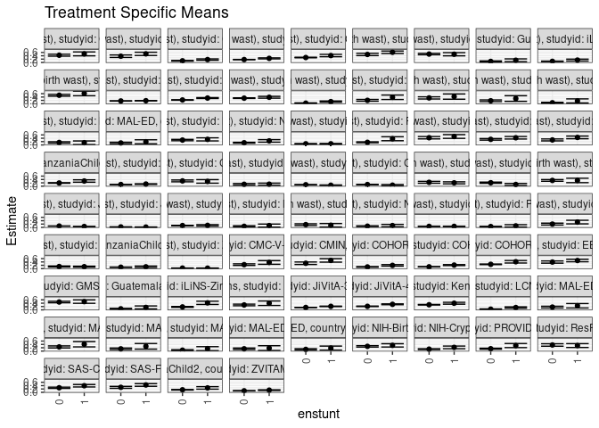

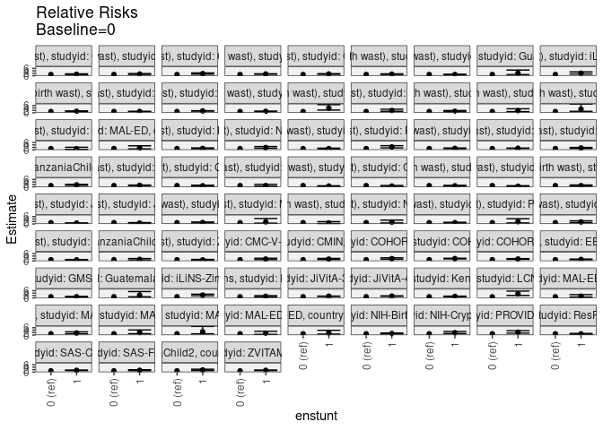

[figure not shown]

[figure not shown]

## Results Table

### Parameter: TSM

| agecat | studyid | country | intervention_level | baseline_level | estimate | ci_lower | ci_upper |
| --- | --- | --- | --- | --- | --- | --- | --- |
| 0-24 months (no birth wast) | CMC-V-BCS-2002 | INDIA | 0 | NA | 0.4351269 | 0.3781234 | 0.4921304 |
| 0-24 months (no birth wast) | CMC-V-BCS-2002 | INDIA | 1 | NA | 0.5155229 | 0.3983026 | 0.6327432 |
| 0-24 months (no birth wast) | CMIN | BANGLADESH | 0 | NA | 0.3757153 | 0.3016348 | 0.4497958 |
| 0-24 months (no birth wast) | CMIN | BANGLADESH | 1 | NA | 0.5161472 | 0.4184787 | 0.6138157 |
| 0-24 months (no birth wast) | COHORTS | GUATEMALA | 0 | NA | 0.1011073 | 0.0825361 | 0.1196785 |
| 0-24 months (no birth wast) | COHORTS | GUATEMALA | 1 | NA | 0.1743881 | 0.1326905 | 0.2160857 |
| 0-24 months (no birth wast) | COHORTS | INDIA | 0 | NA | 0.1751021 | 0.1657210 | 0.1844832 |
| 0-24 months (no birth wast) | COHORTS | INDIA | 1 | NA | 0.2462039 | 0.2170228 | 0.2753851 |
| 0-24 months (no birth wast) | COHORTS | PHILIPPINES | 0 | NA | 0.2964766 | 0.2797060 | 0.3132471 |
| 0-24 months (no birth wast) | COHORTS | PHILIPPINES | 1 | NA | 0.4146150 | 0.3423892 | 0.4868409 |
| 0-24 months (no birth wast) | EE | PAKISTAN | 0 | NA | 0.4807446 | 0.4127545 | 0.5487347 |
| 0-24 months (no birth wast) | EE | PAKISTAN | 1 | NA | 0.6103242 | 0.5367943 | 0.6838542 |
| 0-24 months (no birth wast) | GMS-Nepal | NEPAL | 0 | NA | 0.5027305 | 0.4609873 | 0.5444736 |
| 0-24 months (no birth wast) | GMS-Nepal | NEPAL | 1 | NA | 0.4938049 | 0.3984786 | 0.5891312 |
| 0-24 months (no birth wast) | Guatemala BSC | GUATEMALA | 0 | NA | 0.0632294 | 0.0324091 | 0.0940497 |
| 0-24 months (no birth wast) | Guatemala BSC | GUATEMALA | 1 | NA | 0.1331906 | 0.0503469 | 0.2160344 |
| 0-24 months (no birth wast) | iLiNS-Zinc | BURKINA FASO | 0 | NA | 0.0689724 | 0.0541004 | 0.0838444 |
| 0-24 months (no birth wast) | iLiNS-Zinc | BURKINA FASO | 1 | NA | 0.1437332 | 0.0876747 | 0.1997917 |
| 0-24 months (no birth wast) | IRC | INDIA | 0 | NA | 0.5064920 | 0.4545164 | 0.5584677 |
| 0-24 months (no birth wast) | IRC | INDIA | 1 | NA | 0.6140219 | 0.4771232 | 0.7509207 |
| 0-24 months (no birth wast) | JiVitA-3 | BANGLADESH | 0 | NA | 0.1653323 | 0.1590504 | 0.1716141 |
| 0-24 months (no birth wast) | JiVitA-3 | BANGLADESH | 1 | NA | 0.1805106 | 0.1710867 | 0.1899345 |
| 0-24 months (no birth wast) | JiVitA-4 | BANGLADESH | 0 | NA | 0.2244064 | 0.2091230 | 0.2396899 |
| 0-24 months (no birth wast) | JiVitA-4 | BANGLADESH | 1 | NA | 0.3390026 | 0.3121013 | 0.3659038 |
| 0-24 months (no birth wast) | Keneba | GAMBIA | 0 | NA | 0.3328979 | 0.3146169 | 0.3511788 |
| 0-24 months (no birth wast) | Keneba | GAMBIA | 1 | NA | 0.3858203 | 0.3317022 | 0.4399384 |
| 0-24 months (no birth wast) | LCNI-5 | MALAWI | 0 | NA | 0.0329593 | 0.0176219 | 0.0482966 |
| 0-24 months (no birth wast) | LCNI-5 | MALAWI | 1 | NA | 0.1263412 | 0.0894024 | 0.1632800 |
| 0-24 months (no birth wast) | MAL-ED | BANGLADESH | 0 | NA | 0.2025072 | 0.1494634 | 0.2555510 |
| 0-24 months (no birth wast) | MAL-ED | BANGLADESH | 1 | NA | 0.3854061 | 0.2528196 | 0.5179927 |

[output cut: 122 more lines]

### Parameter: E(Y)

| agecat | studyid | country | intervention_level | baseline_level | estimate | ci_lower | ci_upper |
| --- | --- | --- | --- | --- | --- | --- | --- |
| 0-24 months (no birth wast) | CMC-V-BCS-2002 | INDIA | NA | NA | 0.4510870 | 0.4001777 | 0.5019962 |
| 0-24 months (no birth wast) | CMIN | BANGLADESH | NA | NA | 0.4291045 | 0.3697365 | 0.4884725 |
| 0-24 months (no birth wast) | COHORTS | GUATEMALA | NA | NA | 0.1193694 | 0.1019512 | 0.1367875 |
| 0-24 months (no birth wast) | COHORTS | INDIA | NA | NA | 0.1836020 | 0.1746179 | 0.1925860 |
| 0-24 months (no birth wast) | COHORTS | PHILIPPINES | NA | NA | 0.3034117 | 0.2870099 | 0.3198136 |
| 0-24 months (no birth wast) | EE | PAKISTAN | NA | NA | 0.5384615 | 0.4880726 | 0.5888505 |
| 0-24 months (no birth wast) | GMS-Nepal | NEPAL | NA | NA | 0.5015152 | 0.4633406 | 0.5396897 |
| 0-24 months (no birth wast) | Guatemala BSC | GUATEMALA | NA | NA | 0.0830671 | 0.0524436 | 0.1136905 |
| 0-24 months (no birth wast) | iLiNS-Zinc | BURKINA FASO | NA | NA | 0.0850857 | 0.0676201 | 0.1025513 |
| 0-24 months (no birth wast) | IRC | INDIA | NA | NA | 0.5207824 | 0.4723080 | 0.5692568 |
| 0-24 months (no birth wast) | JiVitA-3 | BANGLADESH | NA | NA | 0.1693995 | 0.1641138 | 0.1746853 |
| 0-24 months (no birth wast) | JiVitA-4 | BANGLADESH | NA | NA | 0.2577835 | 0.2441424 | 0.2714247 |
| 0-24 months (no birth wast) | Keneba | GAMBIA | NA | NA | 0.3392608 | 0.3219301 | 0.3565915 |
| 0-24 months (no birth wast) | LCNI-5 | MALAWI | NA | NA | 0.0669056 | 0.0499685 | 0.0838427 |
| 0-24 months (no birth wast) | MAL-ED | BANGLADESH | NA | NA | 0.2205323 | 0.1703290 | 0.2707357 |
| 0-24 months (no birth wast) | MAL-ED | INDIA | NA | NA | 0.3699187 | 0.3094659 | 0.4303715 |
| 0-24 months (no birth wast) | MAL-ED | NEPAL | NA | NA | 0.1924686 | 0.1423823 | 0.2425550 |
| 0-24 months (no birth wast) | MAL-ED | PERU | NA | NA | 0.0695364 | 0.0408008 | 0.0982721 |
| 0-24 months (no birth wast) | MAL-ED | SOUTH AFRICA | NA | NA | 0.1461039 | 0.1065934 | 0.1856144 |
| 0-24 months (no birth wast) | MAL-ED | TANZANIA, UNITED REPUBLIC OF | NA | NA | 0.1302682 | 0.0893541 | 0.1711823 |
| 0-24 months (no birth wast) | NIH-Birth | BANGLADESH | NA | NA | 0.2956811 | 0.2591967 | 0.3321655 |
| 0-24 months (no birth wast) | NIH-Crypto | BANGLADESH | NA | NA | 0.1432361 | 0.1182149 | 0.1682572 |
| 0-24 months (no birth wast) | PROBIT | BELARUS | NA | NA | 0.0680135 | 0.0562135 | 0.0798135 |
| 0-24 months (no birth wast) | PROVIDE | BANGLADESH | NA | NA | 0.1775837 | 0.1489858 | 0.2061816 |
| 0-24 months (no birth wast) | ResPak | PAKISTAN | NA | NA | 0.4535714 | 0.3951549 | 0.5119879 |
| 0-24 months (no birth wast) | SAS-CompFeed | INDIA | NA | NA | 0.3615180 | 0.3107193 | 0.4123167 |
| 0-24 months (no birth wast) | SAS-FoodSuppl | INDIA | NA | NA | 0.3602015 | 0.3129196 | 0.4074834 |
| 0-24 months (no birth wast) | TanzaniaChild2 | TANZANIA, UNITED REPUBLIC OF | NA | NA | 0.1988255 | 0.1828010 | 0.2148500 |
| 0-24 months (no birth wast) | ZVITAMBO | ZIMBABWE | NA | NA | 0.1020019 | 0.0969221 | 0.1070817 |
| 0-6 months (no birth wast) | CMC-V-BCS-2002 | INDIA | NA | NA | 0.3085714 | 0.2601110 | 0.3570318 |
| 0-6 months (no birth wast) | CMIN | BANGLADESH | NA | NA | 0.1161049 | 0.0776073 | 0.1546024 |
| 0-6 months (no birth wast) | COHORTS | INDIA | NA | NA | 0.0820277 | 0.0753613 | 0.0886940 |
| 0-6 months (no birth wast) | COHORTS | PHILIPPINES | NA | NA | 0.0947298 | 0.0842456 | 0.1052141 |
| 0-6 months (no birth wast) | EE | PAKISTAN | NA | NA | 0.2160000 | 0.1742941 | 0.2577059 |
| 0-6 months (no birth wast) | GMS-Nepal | NEPAL | NA | NA | 0.1915888 | 0.1611224 | 0.2220551 |
| 0-6 months (no birth wast) | IRC | INDIA | NA | NA | 0.3410256 | 0.2939169 | 0.3881343 |
| 0-6 months (no birth wast) | JiVitA-3 | BANGLADESH | NA | NA | 0.0717008 | 0.0680635 | 0.0753382 |
| 0-6 months (no birth wast) | JiVitA-4 | BANGLADESH | NA | NA | 0.0256203 | 0.0209093 | 0.0303314 |
| 0-6 months (no birth wast) | Keneba | GAMBIA | NA | NA | 0.1117987 | 0.0992515 | 0.1243458 |
| 0-6 months (no birth wast) | MAL-ED | BANGLADESH | NA | NA | 0.0725191 | 0.0410556 | 0.1039825 |
| 0-6 months (no birth wast) | MAL-ED | INDIA | NA | NA | 0.1598361 | 0.1137612 | 0.2059110 |
| 0-6 months (no birth wast) | NIH-Birth | BANGLADESH | NA | NA | 0.0787671 | 0.0569010 | 0.1006332 |
| 0-6 months (no birth wast) | PROBIT | BELARUS | NA | NA | 0.0612233 | 0.0502388 | 0.0722078 |
| 0-6 months (no birth wast) | PROVIDE | BANGLADESH | NA | NA | 0.0541728 | 0.0371844 | 0.0711612 |
| 0-6 months (no birth wast) | ResPak | PAKISTAN | NA | NA | 0.2282609 | 0.1786550 | 0.2778667 |
| 0-6 months (no birth wast) | SAS-CompFeed | INDIA | NA | NA | 0.1255940 | 0.0954030 | 0.1557851 |
| 0-6 months (no birth wast) | TanzaniaChild2 | TANZANIA, UNITED REPUBLIC OF | NA | NA | 0.0858586 | 0.0745914 | 0.0971258 |
| 0-6 months (no birth wast) | ZVITAMBO | ZIMBABWE | NA | NA | 0.0319976 | 0.0290150 | 0.0349802 |
| 6-24 months | CMC-V-BCS-2002 | INDIA | NA | NA | 0.2654155 | 0.2205451 | 0.3102860 |
| 6-24 months | CMIN | BANGLADESH | NA | NA | 0.3849206 | 0.3247254 | 0.4451159 |
| 6-24 months | COHORTS | GUATEMALA | NA | NA | 0.1262295 | 0.1075861 | 0.1448729 |
| 6-24 months | COHORTS | INDIA | NA | NA | 0.1226048 | 0.1148883 | 0.1303213 |
| 6-24 months | COHORTS | PHILIPPINES | NA | NA | 0.2666429 | 0.2502871 | 0.2829988 |
| 6-24 months | EE | PAKISTAN | NA | NA | 0.4304813 | 0.3802326 | 0.4807300 |
| 6-24 months | GMS-Nepal | NEPAL | NA | NA | 0.4728814 | 0.4325613 | 0.5132014 |
| 6-24 months | Guatemala BSC | GUATEMALA | NA | NA | 0.0830325 | 0.0504792 | 0.1155858 |
| 6-24 months | iLiNS-Zinc | BURKINA FASO | NA | NA | 0.2317820 | 0.2038933 | 0.2596707 |
| 6-24 months | IRC | INDIA | NA | NA | 0.3097561 | 0.2649438 | 0.3545684 |
| 6-24 months | JiVitA-3 | BANGLADESH | NA | NA | 0.1640074 | 0.1578946 | 0.1701202 |
| 6-24 months | JiVitA-4 | BANGLADESH | NA | NA | 0.2473297 | 0.2337864 | 0.2608729 |
| 6-24 months | Keneba | GAMBIA | NA | NA | 0.3166545 | 0.2992274 | 0.3340815 |
| 6-24 months | LCNI-5 | MALAWI | NA | NA | 0.0774818 | 0.0592383 | 0.0957254 |
| 6-24 months | MAL-ED | BANGLADESH | NA | NA | 0.1791667 | 0.1305478 | 0.2277856 |
| 6-24 months | MAL-ED | INDIA | NA | NA | 0.2723404 | 0.2153029 | 0.3293779 |
| 6-24 months | MAL-ED | NEPAL | NA | NA | 0.1531915 | 0.1070438 | 0.1993392 |
| 6-24 months | MAL-ED | PERU | NA | NA | 0.0666667 | 0.0368579 | 0.0964755 |
| 6-24 months | MAL-ED | SOUTH AFRICA | NA | NA | 0.1428571 | 0.1001583 | 0.1855560 |
| 6-24 months | MAL-ED | TANZANIA, UNITED REPUBLIC OF | NA | NA | 0.1142857 | 0.0743652 | 0.1542062 |
| 6-24 months | NIH-Birth | BANGLADESH | NA | NA | 0.2933579 | 0.2549918 | 0.3317241 |
| 6-24 months | NIH-Crypto | BANGLADESH | NA | NA | 0.1315068 | 0.1069744 | 0.1560393 |
| 6-24 months | PROVIDE | BANGLADESH | NA | NA | 0.1609756 | 0.1319065 | 0.1900447 |
| 6-24 months | ResPak | PAKISTAN | NA | NA | 0.3644068 | 0.3028753 | 0.4259382 |
| 6-24 months | SAS-CompFeed | INDIA | NA | NA | 0.3059755 | 0.2638053 | 0.3481458 |
| 6-24 months | SAS-FoodSuppl | INDIA | NA | NA | 0.3557214 | 0.3088651 | 0.4025777 |
| 6-24 months | TanzaniaChild2 | TANZANIA, UNITED REPUBLIC OF | NA | NA | 0.1605550 | 0.1445335 | 0.1765765 |
| 6-24 months | ZVITAMBO | ZIMBABWE | NA | NA | 0.0958853 | 0.0903360 | 0.1014347 |

### Parameter: RR

| agecat | studyid | country | intervention_level | baseline_level | estimate | ci_lower | ci_upper |
| --- | --- | --- | --- | --- | --- | --- | --- |
| 0-24 months (no birth wast) | CMC-V-BCS-2002 | INDIA | 0 | 0 | 1.0000000 | 1.0000000 | 1.0000000 |
| 0-24 months (no birth wast) | CMC-V-BCS-2002 | INDIA | 1 | 0 | 1.1847645 | 0.9112743 | 1.5403343 |
| 0-24 months (no birth wast) | CMIN | BANGLADESH | 0 | 0 | 1.0000000 | 1.0000000 | 1.0000000 |
| 0-24 months (no birth wast) | CMIN | BANGLADESH | 1 | 0 | 1.3737723 | 1.0451767 | 1.8056758 |
| 0-24 months (no birth wast) | COHORTS | GUATEMALA | 0 | 0 | 1.0000000 | 1.0000000 | 1.0000000 |
| 0-24 months (no birth wast) | COHORTS | GUATEMALA | 1 | 0 | 1.7247819 | 1.2755832 | 2.3321667 |
| 0-24 months (no birth wast) | COHORTS | INDIA | 0 | 0 | 1.0000000 | 1.0000000 | 1.0000000 |
| 0-24 months (no birth wast) | COHORTS | INDIA | 1 | 0 | 1.4060592 | 1.2347501 | 1.6011357 |
| 0-24 months (no birth wast) | COHORTS | PHILIPPINES | 0 | 0 | 1.0000000 | 1.0000000 | 1.0000000 |
| 0-24 months (no birth wast) | COHORTS | PHILIPPINES | 1 | 0 | 1.3984749 | 1.1649465 | 1.6788171 |
| 0-24 months (no birth wast) | EE | PAKISTAN | 0 | 0 | 1.0000000 | 1.0000000 | 1.0000000 |
| 0-24 months (no birth wast) | EE | PAKISTAN | 1 | 0 | 1.2695395 | 1.0547359 | 1.5280893 |
| 0-24 months (no birth wast) | GMS-Nepal | NEPAL | 0 | 0 | 1.0000000 | 1.0000000 | 1.0000000 |
| 0-24 months (no birth wast) | GMS-Nepal | NEPAL | 1 | 0 | 0.9822459 | 0.7962363 | 1.2117093 |
| 0-24 months (no birth wast) | Guatemala BSC | GUATEMALA | 0 | 0 | 1.0000000 | 1.0000000 | 1.0000000 |
| 0-24 months (no birth wast) | Guatemala BSC | GUATEMALA | 1 | 0 | 2.1064669 | 0.9547757 | 4.6473772 |
| 0-24 months (no birth wast) | iLiNS-Zinc | BURKINA FASO | 0 | 0 | 1.0000000 | 1.0000000 | 1.0000000 |
| 0-24 months (no birth wast) | iLiNS-Zinc | BURKINA FASO | 1 | 0 | 2.0839230 | 1.3873179 | 3.1303102 |
| 0-24 months (no birth wast) | IRC | INDIA | 0 | 0 | 1.0000000 | 1.0000000 | 1.0000000 |
| 0-24 months (no birth wast) | IRC | INDIA | 1 | 0 | 1.2123032 | 0.9484135 | 1.5496186 |
| 0-24 months (no birth wast) | JiVitA-3 | BANGLADESH | 0 | 0 | 1.0000000 | 1.0000000 | 1.0000000 |
| 0-24 months (no birth wast) | JiVitA-3 | BANGLADESH | 1 | 0 | 1.0918051 | 1.0251660 | 1.1627759 |
| 0-24 months (no birth wast) | JiVitA-4 | BANGLADESH | 0 | 0 | 1.0000000 | 1.0000000 | 1.0000000 |
| 0-24 months (no birth wast) | JiVitA-4 | BANGLADESH | 1 | 0 | 1.5106632 | 1.3642973 | 1.6727316 |
| 0-24 months (no birth wast) | Keneba | GAMBIA | 0 | 0 | 1.0000000 | 1.0000000 | 1.0000000 |
| 0-24 months (no birth wast) | Keneba | GAMBIA | 1 | 0 | 1.1589750 | 0.9970905 | 1.3471427 |
| 0-24 months (no birth wast) | LCNI-5 | MALAWI | 0 | 0 | 1.0000000 | 1.0000000 | 1.0000000 |
| 0-24 months (no birth wast) | LCNI-5 | MALAWI | 1 | 0 | 3.8332511 | 2.2091093 | 6.6514651 |
| 0-24 months (no birth wast) | MAL-ED | BANGLADESH | 0 | 0 | 1.0000000 | 1.0000000 | 1.0000000 |
| 0-24 months (no birth wast) | MAL-ED | BANGLADESH | 1 | 0 | 1.9031727 | 1.2397825 | 2.9215337 |

[output cut: 122 more lines]

### Parameter: PAR

| agecat | studyid | country | intervention_level | baseline_level | estimate | ci_lower | ci_upper |
| --- | --- | --- | --- | --- | --- | --- | --- |
| 0-24 months (no birth wast) | CMC-V-BCS-2002 | INDIA | 0 | NA | 0.0159601 | -0.0102542 | 0.0421743 |
| 0-24 months (no birth wast) | CMIN | BANGLADESH | 0 | NA | 0.0533892 | 0.0058785 | 0.1008999 |
| 0-24 months (no birth wast) | COHORTS | GUATEMALA | 0 | NA | 0.0182620 | 0.0071587 | 0.0293653 |
| 0-24 months (no birth wast) | COHORTS | INDIA | 0 | NA | 0.0084999 | 0.0048301 | 0.0121697 |
| 0-24 months (no birth wast) | COHORTS | PHILIPPINES | 0 | NA | 0.0069352 | 0.0025733 | 0.0112970 |
| 0-24 months (no birth wast) | EE | PAKISTAN | 0 | NA | 0.0577170 | 0.0131653 | 0.1022686 |
| 0-24 months (no birth wast) | GMS-Nepal | NEPAL | 0 | NA | -0.0012153 | -0.0179493 | 0.0155187 |
| 0-24 months (no birth wast) | Guatemala BSC | GUATEMALA | 0 | NA | 0.0198377 | -0.0011937 | 0.0408691 |
| 0-24 months (no birth wast) | iLiNS-Zinc | BURKINA FASO | 0 | NA | 0.0161133 | 0.0073795 | 0.0248472 |
| 0-24 months (no birth wast) | IRC | INDIA | 0 | NA | 0.0142903 | -0.0041699 | 0.0327506 |
| 0-24 months (no birth wast) | JiVitA-3 | BANGLADESH | 0 | NA | 0.0040673 | 0.0005527 | 0.0075819 |
| 0-24 months (no birth wast) | JiVitA-4 | BANGLADESH | 0 | NA | 0.0333771 | 0.0247201 | 0.0420341 |
| 0-24 months (no birth wast) | Keneba | GAMBIA | 0 | NA | 0.0063629 | 0.0000920 | 0.0126339 |
| 0-24 months (no birth wast) | LCNI-5 | MALAWI | 0 | NA | 0.0339463 | 0.0189762 | 0.0489165 |
| 0-24 months (no birth wast) | MAL-ED | BANGLADESH | 0 | NA | 0.0180251 | -0.0072964 | 0.0433466 |
| 0-24 months (no birth wast) | MAL-ED | INDIA | 0 | NA | 0.0225804 | -0.0060490 | 0.0512098 |
| 0-24 months (no birth wast) | MAL-ED | NEPAL | 0 | NA | 0.0162781 | -0.0058443 | 0.0384006 |
| 0-24 months (no birth wast) | MAL-ED | PERU | 0 | NA | 0.0131454 | -0.0022995 | 0.0285904 |
| 0-24 months (no birth wast) | MAL-ED | SOUTH AFRICA | 0 | NA | -0.0020443 | -0.0163339 | 0.0122454 |
| 0-24 months (no birth wast) | MAL-ED | TANZANIA, UNITED REPUBLIC OF | 0 | NA | 0.0115467 | -0.0090588 | 0.0321522 |
| 0-24 months (no birth wast) | NIH-Birth | BANGLADESH | 0 | NA | 0.0032321 | -0.0129898 | 0.0194540 |
| 0-24 months (no birth wast) | NIH-Crypto | BANGLADESH | 0 | NA | 0.0116514 | -0.0002612 | 0.0235640 |
| 0-24 months (no birth wast) | PROBIT | BELARUS | 0 | NA | 0.0000013 | -0.0005524 | 0.0005550 |
| 0-24 months (no birth wast) | PROVIDE | BANGLADESH | 0 | NA | 0.0197192 | 0.0073828 | 0.0320555 |
| 0-24 months (no birth wast) | ResPak | PAKISTAN | 0 | NA | 0.0216558 | -0.0162360 | 0.0595476 |
| 0-24 months (no birth wast) | SAS-CompFeed | INDIA | 0 | NA | 0.0260710 | 0.0123371 | 0.0398049 |
| 0-24 months (no birth wast) | SAS-FoodSuppl | INDIA | 0 | NA | 0.0601343 | 0.0216578 | 0.0986108 |
| 0-24 months (no birth wast) | TanzaniaChild2 | TANZANIA, UNITED REPUBLIC OF | 0 | NA | 0.0071810 | 0.0021447 | 0.0122173 |
| 0-24 months (no birth wast) | ZVITAMBO | ZIMBABWE | 0 | NA | 0.0029053 | 0.0010125 | 0.0047981 |
| 0-6 months (no birth wast) | CMC-V-BCS-2002 | INDIA | 0 | NA | -0.0063574 | -0.0303532 | 0.0176385 |
| 0-6 months (no birth wast) | CMIN | BANGLADESH | 0 | NA | 0.0030102 | -0.0269399 | 0.0329604 |
| 0-6 months (no birth wast) | COHORTS | INDIA | 0 | NA | -0.0032575 | -0.0052900 | -0.0012251 |
| 0-6 months (no birth wast) | COHORTS | PHILIPPINES | 0 | NA | -0.0018829 | -0.0041094 | 0.0003436 |
| 0-6 months (no birth wast) | EE | PAKISTAN | 0 | NA | -0.0156942 | -0.0525101 | 0.0211216 |
| 0-6 months (no birth wast) | GMS-Nepal | NEPAL | 0 | NA | -0.0150724 | -0.0269573 | -0.0031875 |
| 0-6 months (no birth wast) | IRC | INDIA | 0 | NA | -0.0027097 | -0.0209213 | 0.0155020 |
| 0-6 months (no birth wast) | JiVitA-3 | BANGLADESH | 0 | NA | -0.0084747 | -0.0107902 | -0.0061591 |
| 0-6 months (no birth wast) | JiVitA-4 | BANGLADESH | 0 | NA | -0.0026114 | -0.0053317 | 0.0001090 |
| 0-6 months (no birth wast) | Keneba | GAMBIA | 0 | NA | 0.0009156 | -0.0033221 | 0.0051532 |
| 0-6 months (no birth wast) | MAL-ED | BANGLADESH | 0 | NA | 0.0077043 | -0.0092607 | 0.0246693 |
| 0-6 months (no birth wast) | MAL-ED | INDIA | 0 | NA | -0.0060176 | -0.0247773 | 0.0127421 |
| 0-6 months (no birth wast) | NIH-Birth | BANGLADESH | 0 | NA | 0.0060260 | -0.0047246 | 0.0167766 |
| 0-6 months (no birth wast) | PROBIT | BELARUS | 0 | NA | 0.0000025 | -0.0004502 | 0.0004551 |
| 0-6 months (no birth wast) | PROVIDE | BANGLADESH | 0 | NA | 0.0040110 | -0.0029505 | 0.0109724 |
| 0-6 months (no birth wast) | ResPak | PAKISTAN | 0 | NA | 0.0298981 | -0.0043716 | 0.0641678 |
| 0-6 months (no birth wast) | SAS-CompFeed | INDIA | 0 | NA | -0.0005332 | -0.0063999 | 0.0053336 |
| 0-6 months (no birth wast) | TanzaniaChild2 | TANZANIA, UNITED REPUBLIC OF | 0 | NA | 0.0009844 | -0.0022594 | 0.0042281 |
| 0-6 months (no birth wast) | ZVITAMBO | ZIMBABWE | 0 | NA | -0.0003842 | -0.0013287 | 0.0005603 |
| 6-24 months | CMC-V-BCS-2002 | INDIA | 0 | NA | 0.0272001 | 0.0021349 | 0.0522654 |
| 6-24 months | CMIN | BANGLADESH | 0 | NA | 0.0622502 | 0.0144504 | 0.1100501 |
| 6-24 months | COHORTS | GUATEMALA | 0 | NA | 0.0237248 | 0.0112409 | 0.0362088 |
| 6-24 months | COHORTS | INDIA | 0 | NA | 0.0128057 | 0.0092126 | 0.0163988 |
| 6-24 months | COHORTS | PHILIPPINES | 0 | NA | 0.0088337 | 0.0042309 | 0.0134366 |
| 6-24 months | EE | PAKISTAN | 0 | NA | 0.0369980 | -0.0075458 | 0.0815418 |
| 6-24 months | GMS-Nepal | NEPAL | 0 | NA | 0.0034685 | -0.0144396 | 0.0213766 |
| 6-24 months | Guatemala BSC | GUATEMALA | 0 | NA | 0.0207875 | -0.0018885 | 0.0434635 |
| 6-24 months | iLiNS-Zinc | BURKINA FASO | 0 | NA | 0.0555371 | 0.0361162 | 0.0749579 |
| 6-24 months | IRC | INDIA | 0 | NA | 0.0154627 | -0.0027317 | 0.0336570 |
| 6-24 months | JiVitA-3 | BANGLADESH | 0 | NA | 0.0196466 | 0.0154306 | 0.0238627 |
| 6-24 months | JiVitA-4 | BANGLADESH | 0 | NA | 0.0349675 | 0.0263252 | 0.0436098 |
| 6-24 months | Keneba | GAMBIA | 0 | NA | 0.0108729 | 0.0042608 | 0.0174850 |
| 6-24 months | LCNI-5 | MALAWI | 0 | NA | 0.0362962 | 0.0201533 | 0.0524391 |
| 6-24 months | MAL-ED | BANGLADESH | 0 | NA | 0.0132057 | -0.0097594 | 0.0361708 |
| 6-24 months | MAL-ED | INDIA | 0 | NA | 0.0222154 | -0.0059667 | 0.0503975 |
| 6-24 months | MAL-ED | NEPAL | 0 | NA | 0.0179258 | -0.0037337 | 0.0395852 |
| 6-24 months | MAL-ED | PERU | 0 | NA | 0.0115819 | -0.0043035 | 0.0274673 |
| 6-24 months | MAL-ED | SOUTH AFRICA | 0 | NA | 0.0043290 | -0.0118481 | 0.0205061 |
| 6-24 months | MAL-ED | TANZANIA, UNITED REPUBLIC OF | 0 | NA | 0.0123440 | -0.0082762 | 0.0329641 |
| 6-24 months | NIH-Birth | BANGLADESH | 0 | NA | 0.0092970 | -0.0075826 | 0.0261767 |
| 6-24 months | NIH-Crypto | BANGLADESH | 0 | NA | 0.0145974 | 0.0025047 | 0.0266901 |
| 6-24 months | PROVIDE | BANGLADESH | 0 | NA | 0.0185951 | 0.0055983 | 0.0315919 |
| 6-24 months | ResPak | PAKISTAN | 0 | NA | -0.0014393 | -0.0419330 | 0.0390543 |
| 6-24 months | SAS-CompFeed | INDIA | 0 | NA | 0.0324543 | 0.0149374 | 0.0499712 |
| 6-24 months | SAS-FoodSuppl | INDIA | 0 | NA | 0.0564356 | 0.0175848 | 0.0952864 |
| 6-24 months | TanzaniaChild2 | TANZANIA, UNITED REPUBLIC OF | 0 | NA | 0.0079503 | 0.0026181 | 0.0132825 |
| 6-24 months | ZVITAMBO | ZIMBABWE | 0 | NA | 0.0042219 | 0.0020167 | 0.0064271 |

### Parameter: PAF

| agecat | studyid | country | intervention_level | baseline_level | estimate | ci_lower | ci_upper |
| --- | --- | --- | --- | --- | --- | --- | --- |
| 0-24 months (no birth wast) | CMC-V-BCS-2002 | INDIA | 0 | NA | 0.0353813 | -0.0246171 | 0.0918665 |
| 0-24 months (no birth wast) | CMIN | BANGLADESH | 0 | NA | 0.1244200 | 0.0058942 | 0.2288142 |
| 0-24 months (no birth wast) | COHORTS | GUATEMALA | 0 | NA | 0.1529876 | 0.0569726 | 0.2392267 |
| 0-24 months (no birth wast) | COHORTS | INDIA | 0 | NA | 0.0462951 | 0.0261821 | 0.0659926 |
| 0-24 months (no birth wast) | COHORTS | PHILIPPINES | 0 | NA | 0.0228573 | 0.0083808 | 0.0371225 |
| 0-24 months (no birth wast) | EE | PAKISTAN | 0 | NA | 0.1071886 | 0.0195898 | 0.1869606 |
| 0-24 months (no birth wast) | GMS-Nepal | NEPAL | 0 | NA | -0.0024233 | -0.0363515 | 0.0303943 |
| 0-24 months (no birth wast) | Guatemala BSC | GUATEMALA | 0 | NA | 0.2388154 | -0.0415118 | 0.4436914 |
| 0-24 months (no birth wast) | iLiNS-Zinc | BURKINA FASO | 0 | NA | 0.1893776 | 0.0957011 | 0.2733500 |
| 0-24 months (no birth wast) | IRC | INDIA | 0 | NA | 0.0274401 | -0.0087723 | 0.0623527 |
| 0-24 months (no birth wast) | JiVitA-3 | BANGLADESH | 0 | NA | 0.0240099 | 0.0030437 | 0.0445351 |
| 0-24 months (no birth wast) | JiVitA-4 | BANGLADESH | 0 | NA | 0.1294772 | 0.0953396 | 0.1623266 |
| 0-24 months (no birth wast) | Keneba | GAMBIA | 0 | NA | 0.0187553 | 0.0000952 | 0.0370672 |
| 0-24 months (no birth wast) | LCNI-5 | MALAWI | 0 | NA | 0.5073766 | 0.2786091 | 0.6635973 |
| 0-24 months (no birth wast) | MAL-ED | BANGLADESH | 0 | NA | 0.0817347 | -0.0393910 | 0.1887450 |
| 0-24 months (no birth wast) | MAL-ED | INDIA | 0 | NA | 0.0610415 | -0.0196644 | 0.1353596 |
| 0-24 months (no birth wast) | MAL-ED | NEPAL | 0 | NA | 0.0845756 | -0.0365399 | 0.1915392 |
| 0-24 months (no birth wast) | MAL-ED | PERU | 0 | NA | 0.1890440 | -0.0502559 | 0.3738197 |
| 0-24 months (no birth wast) | MAL-ED | SOUTH AFRICA | 0 | NA | -0.0139918 | -0.1166164 | 0.0792010 |
| 0-24 months (no birth wast) | MAL-ED | TANZANIA, UNITED REPUBLIC OF | 0 | NA | 0.0886382 | -0.0819673 | 0.2323425 |
| 0-24 months (no birth wast) | NIH-Birth | BANGLADESH | 0 | NA | 0.0109311 | -0.0454664 | 0.0642862 |
| 0-24 months (no birth wast) | NIH-Crypto | BANGLADESH | 0 | NA | 0.0813440 | -0.0046014 | 0.1599365 |
| 0-24 months (no birth wast) | PROBIT | BELARUS | 0 | NA | 0.0000195 | -0.0081559 | 0.0081286 |
| 0-24 months (no birth wast) | PROVIDE | BANGLADESH | 0 | NA | 0.1110415 | 0.0403160 | 0.1765548 |
| 0-24 months (no birth wast) | ResPak | PAKISTAN | 0 | NA | 0.0477452 | -0.0397151 | 0.1278483 |
| 0-24 months (no birth wast) | SAS-CompFeed | INDIA | 0 | NA | 0.0721154 | 0.0370108 | 0.1059403 |
| 0-24 months (no birth wast) | SAS-FoodSuppl | INDIA | 0 | NA | 0.1669463 | 0.0532713 | 0.2669723 |
| 0-24 months (no birth wast) | TanzaniaChild2 | TANZANIA, UNITED REPUBLIC OF | 0 | NA | 0.0361170 | 0.0105417 | 0.0610312 |
| 0-24 months (no birth wast) | ZVITAMBO | ZIMBABWE | 0 | NA | 0.0284828 | 0.0097924 | 0.0468203 |
| 0-6 months (no birth wast) | CMC-V-BCS-2002 | INDIA | 0 | NA | -0.0206026 | -0.1014065 | 0.0542732 |
| 0-6 months (no birth wast) | CMIN | BANGLADESH | 0 | NA | 0.0259269 | -0.2692712 | 0.2524699 |
| 0-6 months (no birth wast) | COHORTS | INDIA | 0 | NA | -0.0397125 | -0.0646025 | -0.0154044 |
| 0-6 months (no birth wast) | COHORTS | PHILIPPINES | 0 | NA | -0.0198769 | -0.0435692 | 0.0032775 |
| 0-6 months (no birth wast) | EE | PAKISTAN | 0 | NA | -0.0726585 | -0.2573885 | 0.0849318 |
| 0-6 months (no birth wast) | GMS-Nepal | NEPAL | 0 | NA | -0.0786704 | -0.1418475 | -0.0189888 |
| 0-6 months (no birth wast) | IRC | INDIA | 0 | NA | -0.0079456 | -0.0627847 | 0.0440638 |
| 0-6 months (no birth wast) | JiVitA-3 | BANGLADESH | 0 | NA | -0.1181947 | -0.1500447 | -0.0872267 |
| 0-6 months (no birth wast) | JiVitA-4 | BANGLADESH | 0 | NA | -0.1019266 | -0.2107118 | -0.0029159 |
| 0-6 months (no birth wast) | Keneba | GAMBIA | 0 | NA | 0.0081893 | -0.0304469 | 0.0453768 |
| 0-6 months (no birth wast) | MAL-ED | BANGLADESH | 0 | NA | 0.1062378 | -0.1560655 | 0.3090263 |
| 0-6 months (no birth wast) | MAL-ED | INDIA | 0 | NA | -0.0376485 | -0.1615715 | 0.0730537 |
| 0-6 months (no birth wast) | NIH-Birth | BANGLADESH | 0 | NA | 0.0765044 | -0.0690025 | 0.2022057 |
| 0-6 months (no birth wast) | PROBIT | BELARUS | 0 | NA | 0.0000404 | -0.0073852 | 0.0074113 |
| 0-6 months (no birth wast) | PROVIDE | BANGLADESH | 0 | NA | 0.0740401 | -0.0616406 | 0.1923804 |
| 0-6 months (no birth wast) | ResPak | PAKISTAN | 0 | NA | 0.1309821 | -0.0310376 | 0.2675416 |
| 0-6 months (no birth wast) | SAS-CompFeed | INDIA | 0 | NA | -0.0042451 | -0.0521336 | 0.0414637 |
| 0-6 months (no birth wast) | TanzaniaChild2 | TANZANIA, UNITED REPUBLIC OF | 0 | NA | 0.0114650 | -0.0270214 | 0.0485092 |
| 0-6 months (no birth wast) | ZVITAMBO | ZIMBABWE | 0 | NA | -0.0120062 | -0.0419368 | 0.0170646 |
| 6-24 months | CMC-V-BCS-2002 | INDIA | 0 | NA | 0.1024814 | 0.0035429 | 0.1915962 |
| 6-24 months | CMIN | BANGLADESH | 0 | NA | 0.1617222 | 0.0276707 | 0.2772926 |
| 6-24 months | COHORTS | GUATEMALA | 0 | NA | 0.1879500 | 0.0862519 | 0.2783293 |
| 6-24 months | COHORTS | INDIA | 0 | NA | 0.1044470 | 0.0752675 | 0.1327059 |
| 6-24 months | COHORTS | PHILIPPINES | 0 | NA | 0.0331295 | 0.0157438 | 0.0502081 |
| 6-24 months | EE | PAKISTAN | 0 | NA | 0.0859457 | -0.0239351 | 0.1840350 |
| 6-24 months | GMS-Nepal | NEPAL | 0 | NA | 0.0073348 | -0.0312722 | 0.0444966 |
| 6-24 months | Guatemala BSC | GUATEMALA | 0 | NA | 0.2503537 | -0.0550046 | 0.4673297 |
| 6-24 months | iLiNS-Zinc | BURKINA FASO | 0 | NA | 0.2396090 | 0.1620166 | 0.3100169 |
| 6-24 months | IRC | INDIA | 0 | NA | 0.0499188 | -0.0106743 | 0.1068793 |
| 6-24 months | JiVitA-3 | BANGLADESH | 0 | NA | 0.1197911 | 0.0941874 | 0.1446711 |
| 6-24 months | JiVitA-4 | BANGLADESH | 0 | NA | 0.1413802 | 0.1059298 | 0.1754251 |
| 6-24 months | Keneba | GAMBIA | 0 | NA | 0.0343368 | 0.0132453 | 0.0549774 |
| 6-24 months | LCNI-5 | MALAWI | 0 | NA | 0.4684476 | 0.2566413 | 0.6199036 |
| 6-24 months | MAL-ED | BANGLADESH | 0 | NA | 0.0737061 | -0.0630097 | 0.1928385 |
| 6-24 months | MAL-ED | INDIA | 0 | NA | 0.0815723 | -0.0273743 | 0.1789659 |
| 6-24 months | MAL-ED | NEPAL | 0 | NA | 0.1170156 | -0.0327800 | 0.2450846 |
| 6-24 months | MAL-ED | PERU | 0 | NA | 0.1737288 | -0.0873034 | 0.3720943 |
| 6-24 months | MAL-ED | SOUTH AFRICA | 0 | NA | 0.0303030 | -0.0895376 | 0.1369622 |
| 6-24 months | MAL-ED | TANZANIA, UNITED REPUBLIC OF | 0 | NA | 0.1080097 | -0.0882169 | 0.2688528 |
| 6-24 months | NIH-Birth | BANGLADESH | 0 | NA | 0.0316918 | -0.0275926 | 0.0875559 |
| 6-24 months | NIH-Crypto | BANGLADESH | 0 | NA | 0.1110010 | 0.0160746 | 0.1967692 |
| 6-24 months | PROVIDE | BANGLADESH | 0 | NA | 0.1155152 | 0.0328970 | 0.1910754 |
| 6-24 months | ResPak | PAKISTAN | 0 | NA | -0.0039498 | -0.1214587 | 0.1012463 |
| 6-24 months | SAS-CompFeed | INDIA | 0 | NA | 0.1060683 | 0.0515807 | 0.1574256 |
| 6-24 months | SAS-FoodSuppl | INDIA | 0 | NA | 0.1586511 | 0.0420977 | 0.2610229 |
| 6-24 months | TanzaniaChild2 | TANZANIA, UNITED REPUBLIC OF | 0 | NA | 0.0495178 | 0.0159560 | 0.0819349 |
| 6-24 months | ZVITAMBO | ZIMBABWE | 0 | NA | 0.0440307 | 0.0208719 | 0.0666417 |